# R Notebook

This is the motivation (from Jacobson et al 2016): “We quantified water quality effects of land use by calculating the relative amount of disturbed land within a watershed. A simple, yet direct watershed disturbance variable (percentage of urban, agriculture, and mining land uses in a catchment) was developed by Cross and Jacobson (2013) using National Land Cover Database 2001 land use GIS data. The percentage land use disturbance variable was significant in models predicting total phosphorus concentrations in Minnesota lakes (Cross and Jacobson 2013). Catchments with undisturbed land uses lie primarily in the Northern Forests ecoregion (CEC 1997; Level 1) and generally provide good water quality to lakes and streams in that region (Figure 5). Catchments within the agricultural Great Plains ecoregion have the highest disturbed land uses and appreciably poorer water quality (Heiskary et al. 1987; Ramstack et al. 2004). Catchments in the transition from forest to prairie in the Eastern Temperate Forests ecoregion have a wide range of disturbance values. Cross and Jacobson (2013) noted that phosphorus concentrations generally become elevated when watershed land use disturbance reached 25% and greatly increased when land use disturbances exceeded 60%. These disturbance values set the foundation for the identification of appropriate management strategies for water quality in lakes under this framework. Lakes with relatively undisturbed watersheds need protection, whereas lakes with heavily disturbed watersheds need restoration.”

NOTES:

1. The W:L area was pulled simply as the %open water. This isn’t accurate since it will include other surface waters. We need to pull a more accurate value.

```r
  # setwd("C:/Users/amonion/New York State Office of Information Technology Services/BWAM - Lakes Database/Current")
  # source("new_database/Reading.LMAS.Data.R")
  # setwd("C:/Users/amonion/OneDrive - New York State Office of Information Technology Services/Rscripts/TP_Landuse")

  rm(list=setdiff(ls(), c("newdata")))
```

Family: gaussian Link function: identity

Formula: logTP ~ s(DISTURBANCE, bs = “gp”)

Parametric coefficients: Estimate Std. Error t value Pr(>|t|)  
(Intercept) 1.22339 0.01511 80.96 <2e-16 *** — Signif. codes: 0 ‘**’ 0.001 ‘**’ 0.01 ‘’ 0.05 ‘.’ 0.1 ‘ ’ 1

Approximate significance of smooth terms: edf Ref.df F p-value  
s(DISTURBANCE) 7.252 8.293 27.28 <2e-16 *** — Signif. codes: 0 ‘**’ 0.001 ‘**’ 0.01 ‘’ 0.05 ‘.’ 0.1 ‘ ’ 1

R-sq.(adj) = 0.307 Deviance explained = 31.7% GCV = 0.11699 Scale est. = 0.11508 n = 504

Family: gaussian Link function: identity

Formula: logTP ~ s(DISTURBANCE, bs = “gp”) + s(depth, bs = “gp”) + s(WLarea, bs = “gp”)

Parametric coefficients: Estimate Std. Error t value Pr(>|t|)  
(Intercept) 1.17219 0.01934 60.6 <2e-16 *** — Signif. codes: 0 ‘**’ 0.001 ‘**’ 0.01 ‘’ 0.05 ‘.’ 0.1 ‘ ’ 1

Approximate significance of smooth terms: edf Ref.df F p-value  
s(DISTURBANCE) 3.278 4.092 39.585 <2e-16 *s(depth) 5.695 6.815 14.428 <2e-16* s(WLarea) 2.271 2.843 2.262 0.0786 .  
— Signif. codes: 0 ‘**’ 0.001 ‘**’ 0.01 ‘’ 0.05 ‘.’ 0.1 ‘ ’ 1

R-sq.(adj) = 0.591 Deviance explained = 61.2% GCV = 0.08604 Scale est. = 0.081185 n = 217

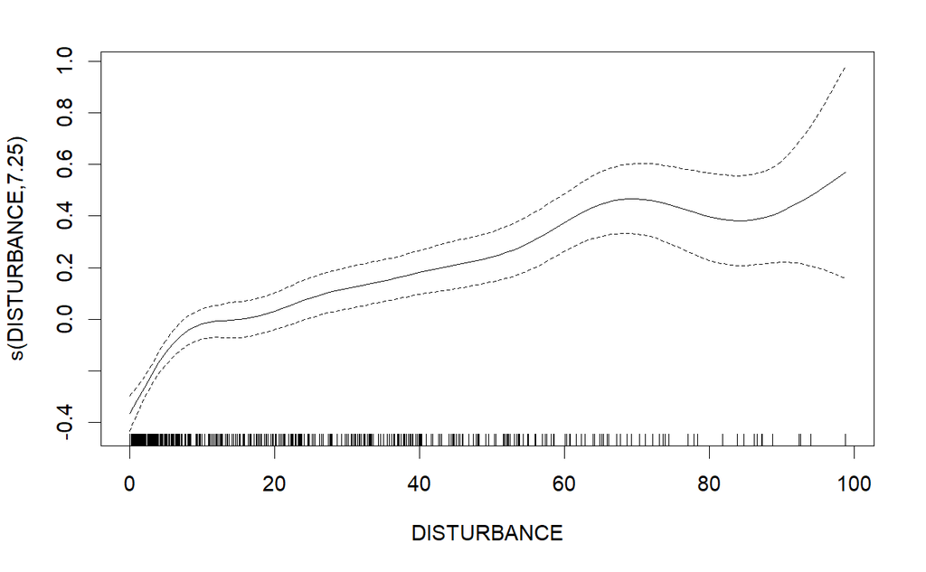

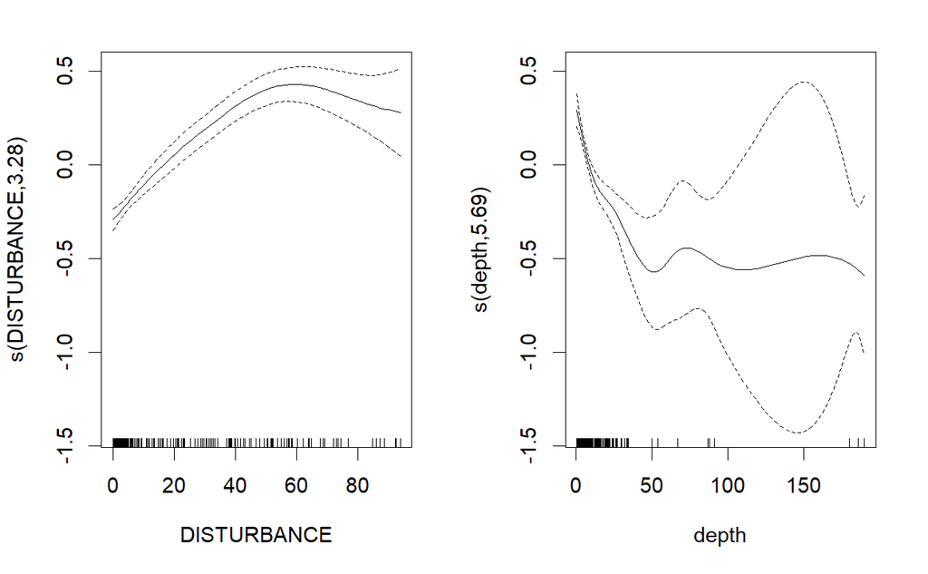

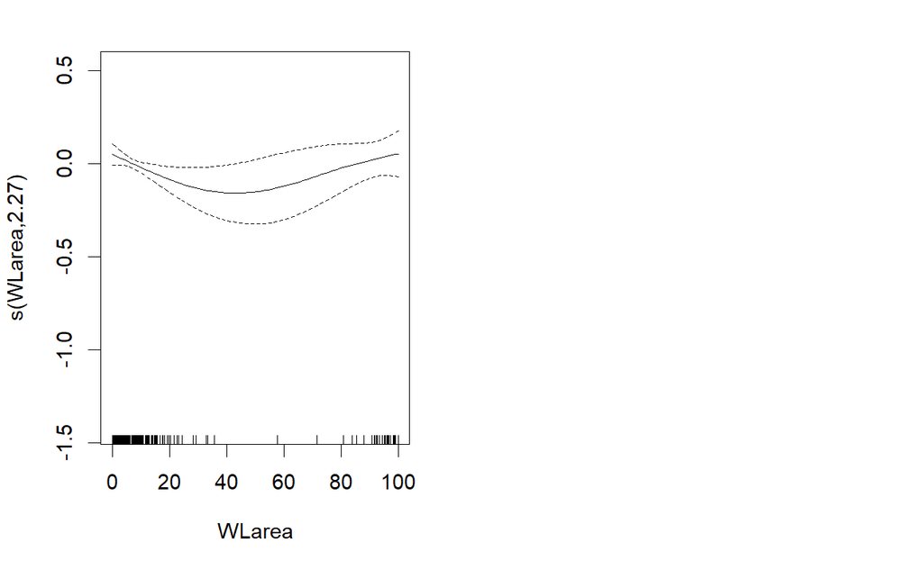